# Inspection and visualization of breast cancer data

12-May-2021

## Introduction

## Overview of data

- **File**: 77_cancer_proteomes_CPTAC_itraq.csv
  - Gene expression data from 77 cancer patients and 3 healthy persons.
- **File**: clinical_data_breast_cancer.csv
  - Clinical data from the 77 cancer patients

[Source: Kaggle](https://www.kaggle.com/piotrgrabo/breastcancerproteomes#clinical_data_breast_cancer.csv)

## Github overview

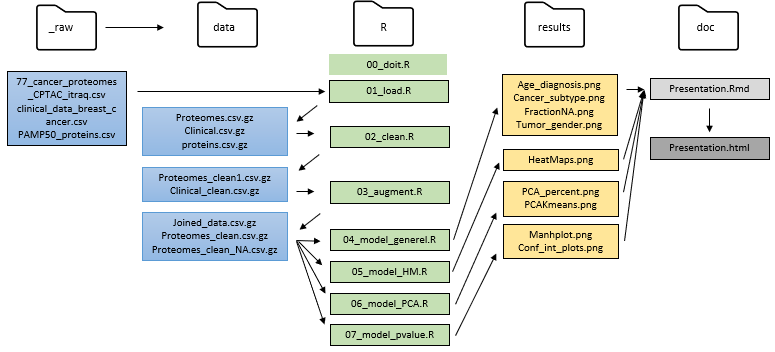

## Materials and methods

## Materials: Extract of raw data

**Proteomes**

| RefSeq_accession_number | gene_symbol | gene_name | AO-A12D.01TCGA |
| --- | --- | --- | --- |
| NP_001615 | AIM1 | absent in melanoma 1 protein | -3.5403932 |
| NP_062559 | WDR45L | WD repeat domain phosphoinositide-interacting protein 3 | -1.6354941 |
| NP_001128727 | NA | histone-binding protein RBBP4 isoform b | -0.6144682 |
| NP_006321 | LYPLA1 | acyl-protein thioesterase 1 isoform 1 | -0.6449466 |

**Clinical**

| Complete TCGA ID | Gender | Age at Initial Pathologic Diagnosis | Tumor | PAM50 mRNA |
| --- | --- | --- | --- | --- |
| TCGA-A2-A0T2 | FEMALE | 66 | T3 | Basal-like |
| TCGA-A2-A0CM | FEMALE | 40 | T2 | Basal-like |
| TCGA-BH-A18V | FEMALE | 48 | T2 | Basal-like |
| TCGA-BH-A18Q | FEMALE | 56 | T2 | Basal-like |

## Methods: Cleaning of data

### We had to clean the data in order to use it for analysis

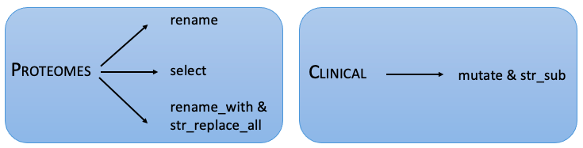

## Methods: Wrangle data

### After the cleaning, the datasets were wrangled and joined

- **Proteomes**:
  - Removing fraction NA > 0.25 using filter()
  - Replace the remaining NAs with median of column
  - Transpose data (get RefSeqProteinID as columns)
- **Joining**:
  - Right_join by TCGA_IDs in proteomes file
    - 28 patients were dropped, 3 healthy patients
  - Age group, HER2 as binary, replace_na() in class

## Materials: Extract of clean data

**Joined data**

| TCGA_ID | Age_group | HER2_binary | Gender | Tumor | Class |
| --- | --- | --- | --- | --- | --- |
| AN-A0AM | 50-60 | 0 | FEMALE | T2 | Luminal B |
| A7-A0CJ | 50-60 | 0 | FEMALE | T2 | Luminal B |
| A2-A0SX | 40-50 | 0 | FEMALE | T1 | Basal-like |
| C8-A138 | 50-60 | 1 | FEMALE | T2 | HER2-enriched |

| NP_001449 | NP_001120959 | NP_003119 | NP_842565 | NP_001020029 | NP_008877 |
| --- | --- | --- | --- | --- | --- |
| -1.0036516 | -1.0036516 | 0.9220201 | 0.9479426 | 3.1550586 | 0.3998668 |
| -1.8598762 | -1.8598762 | -0.6348848 | -0.6875428 | -0.8704601 | -0.0833615 |
| 0.9544696 | 0.9578435 | 1.8148224 | 1.7912049 | -1.4039093 | -1.5658581 |
| 0.6144863 | 0.6144863 | 2.7887982 | 2.8495574 | 4.8849910 | -1.3471683 |

## Results

## Removal for genes according to the fraction of NAs

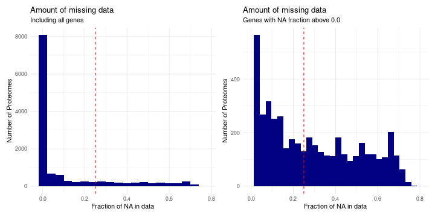

## Age at diagnosis

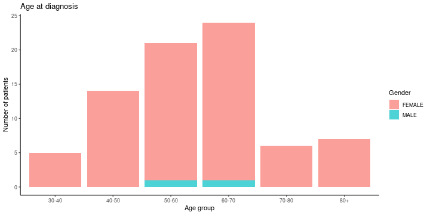

## Tumor, age at diagnosis and gender

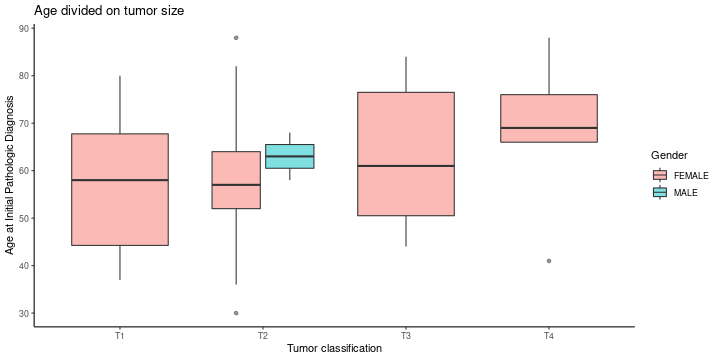

## Subtype of breast cancer

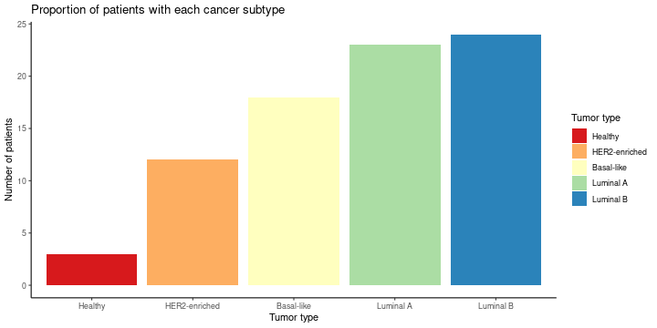

## Extract relevant breast cancer genes

| Gene | Description |
| --- | --- |
| BRCA1 | breast cancer type 1 susceptibility protein isoform 2 |
| TP53 | cellular tumor antigen p53 isoform a |
| CHEK2 | serine/threonine-protein kinase Chk2 isoform a |
| PTEN | phosphatidylinositol 3,4,5-trisphosphate 3-phosphatase |
| CDH1 | cadherin-1 preproprotein |
| STK11 | serine/threonine-protein kinase STK11 |
| ERRB2/HER2 | receptor tyrosine-protein kinase erbB-2 isoform a precursor |
| GATA3 | trans-acting T-cell-specific transcription factor GATA-3 isoform 1 |

[Source: American Cancer Society](https://www.cancer.org/cancer/breast-cancer/risk-and-prevention/breast-cancer-risk-factors-you-cannot-change.html?fbclid=IwAR3_gy68xITNknN36n2uay179hfmhxMrP7UejZKIe5EgtE_1TFGVZQPnaKA)

## Heat map

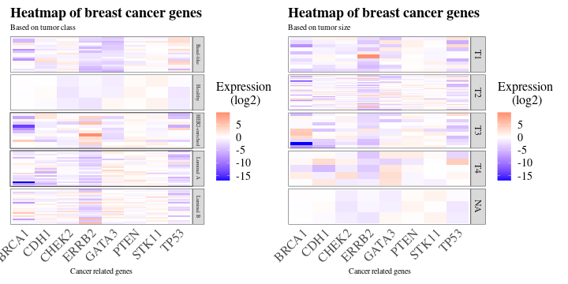

## PCA percent

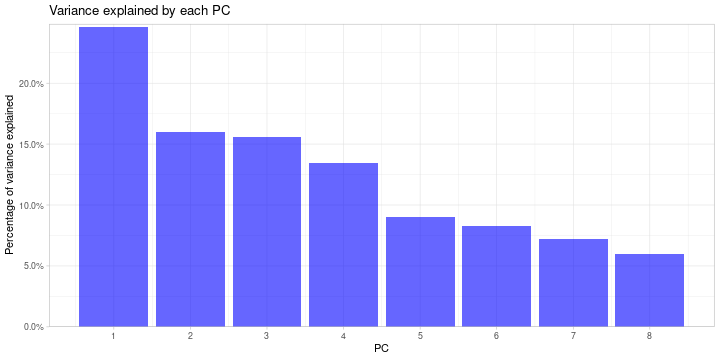

## PCA and K-means

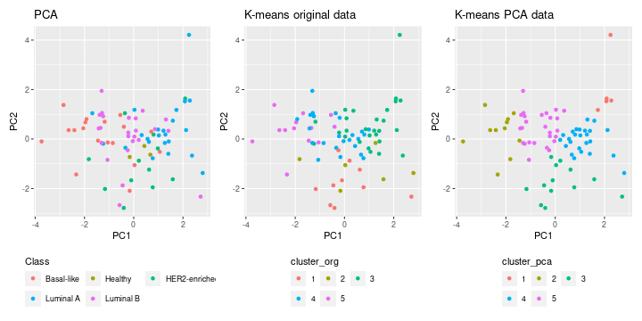

## Linear model extract

```
## # A tibble: 8 x 5
##   RefSeqProteinID statistic  p.value identified_as   neg_log10_p
##   <chr>               <dbl>    <dbl> <chr>                 <dbl>
## 1 NP_004439           3.79  0.000149 Significant           3.83
## 2 NP_004351           1.27  0.203    Non-significant       0.692
## 3 NP_009125          -1.00  0.317    Non-significant       0.499
## 4 NP_000537          -1.27  0.205    Non-significant       0.689
## 5 NP_001002295       -0.538 0.591    Non-significant       0.229
## 6 NP_000305           0.891 0.373    Non-significant       0.429
## 7 NP_009231          -1.48  0.139    Non-significant       0.857
## 8 NP_000446          -1.04  0.300    Non-significant       0.523
```

## Manhattan plot

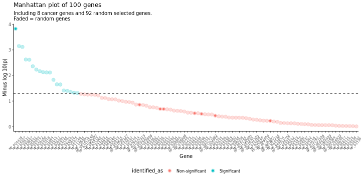

## Discussion

## Handling of NA values

- Limit at 25% ~ 17% genes removed
- Limit at 0% ~ 36% genes removed

### **Replacement by median**

- Avoid NA values
- Not necessary to remove either person or whole gene
- Does not skew the data

## Selection of cancer genes

- Small subset of data
- Improvement for future: identify significant genes across whole dataset
- Findings: HER2/ERRB2 gene significant in Manhattan plot

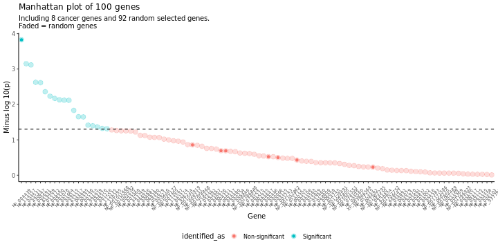

## Additional thoughts

### **Comparison between healthy and diseased**

- Used in PCA analysis and K-means
- Only 3 individuals (no clinical data)

### **Deselection of dataset**

- “Dictionary” of proteins
- Not usefull for our approach
- Could have been used to “translate” RefSeqProteinID’s